# Question

In the table below, various physical quantities and some common units of measure are presented:

| quantity | units of measure |
| --- | --- |
| time | seconds ($\mathrm{s}$) |
| distance | meters ($\mathrm{m}$) |
| velocity | meters per second ($\mathrm{m/s}$) |
| acceleration | meters per squared second ($\mathrm{m/s^2}$) |
| jerk | meters per cubed second ($\mathrm{m/s^3}$) |
| force | Newtons ($\mathrm{N}$) |
| impulse (momentum) | Newton-seconds ($\mathrm{N\cdot s}$) |
| energy | Newton-meters ($\mathrm{N\cdot m}$) |
| energy | Joules ($\mathrm{J}$) |
| energy | kilowatt-hours ($\mathrm{kW\cdot hr}$) |
| power | Newton-meters per second ($\mathrm{\frac{N\cdot m}{s}}$) |
| power | Joules per second ($\mathrm{J/s}$) = Watts ($\mathrm{W}$) |
| power | kilowatt ($\mathrm{kW}$) |
| electrical charge | Coulombs ($\mathrm{C}$) |
| electrical current | Coulombs/second ($\mathrm{C/s}$) = amperes ($\mathrm{A}$) |

A device measures acceleration (in $\mathrm{m/s^2}$) as a function of time (in $\mathrm{s}$). Those measurements are graphed below as a blue curve. Two points are selected, and their [secant line](https://en.wikipedia.org/wiki/Secant_line) is drawn in red.

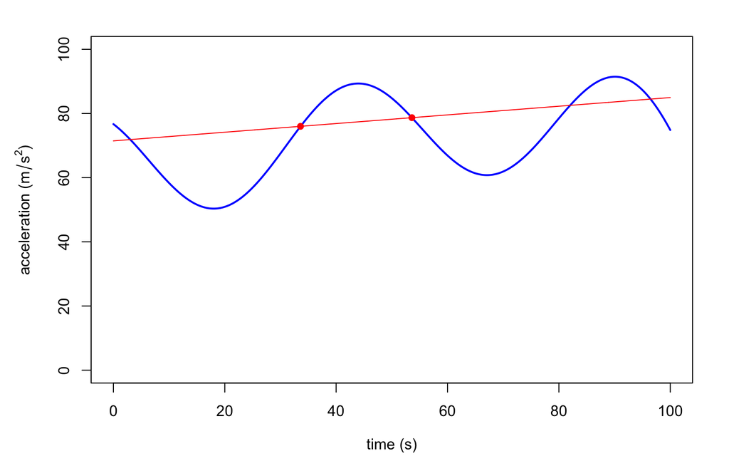

The two marked points are at coordinates (33.6, 76) and (53.6, 78.7). Determine the average rate of change of the acceleration over the given interval of time marked by the two points.

AROC = ##ANSWER1## ##ANSWER2##

This average rate of change is a quantity of ##ANSWER3##.

## Answerlist

- -0.427
- -0.135
- -0.0427
- -0.0135
- -0.00427
- 0.00427
- 0.0135
- 0.0427
- 0.135
- 0.427
- s
- hr
- m
- m/s
- m/s²
- m/s³
- N
- N*s
- N*m
- J
- J/s
- kW
- kW*hr
- C
- C/s
- acceleration
- charge
- current
- distance
- energy
- force
- impulse
- jerk
- power
- time
- velocity

# Solution

$$\mathrm{AROC}~=~\frac{(78.7-76)(\mathrm{m/s^2})}{(53.6-33.6)(\mathrm{s})}$$

$$\mathrm{AROC}~=~\frac{2.7}{20}\,\frac{\mathrm{m/s^2}}{\mathrm{s}}$$

$$\mathrm{AROC}~=~0.135\,\mathrm{m/s^3}$$

Thus when we find the average rate of change of acceleration over an interval of time, the result is a quantity of jerk.

# Meta-information

extype: cloze exclozetype: schoice|schoice|schoice exsolution: 0000000010|000001000000000|00000001000 exname: AROC_dimensions